# ACP for Image Compression

MP Etienne

https://marieetienne.github.io/MAF/

Un bloc de 1- pixels est un individu à 16 variables.

```
[1] 17
```

[output not shown]

[output cut: 27 more lines]

```
      [,1] [,2] [,3] [,4] [,5] [,6] [,7] [,8] [,9] [,10] [,11] [,12] [,13]
 [1,]    1    2    3    4   21   22   23   24   41    42    43    44    61
 [2,]    5    6    7    8   25   26   27   28   45    46    47    48    65
 [3,]    9   10   11   12   29   30   31   32   49    50    51    52    69
 [4,]   13   14   15   16   33   34   35   36   53    54    55    56    73
 [5,]   17   18   19   20   37   38   39   40   57    58    59    60    77
 [6,]   81   82   83   84  101  102  103  104  121   122   123   124   141
 [7,]   85   86   87   88  105  106  107  108  125   126   127   128   145
 [8,]   89   90   91   92  109  110  111  112  129   130   131   132   149
 [9,]   93   94   95   96  113  114  115  116  133   134   135   136   153
[10,]   97   98   99  100  117  118  119  120  137   138   139   140   157
[11,]  161  162  163  164  181  182  183  184  201   202   203   204   221
[12,]  165  166  167  168  185  186  187  188  205   206   207   208   225
[13,]  169  170  171  172  189  190  191  192  209   210   211   212   229
[14,]  173  174  175  176  193  194  195  196  213   214   215   216   233
```

[output cut: 27 more lines]

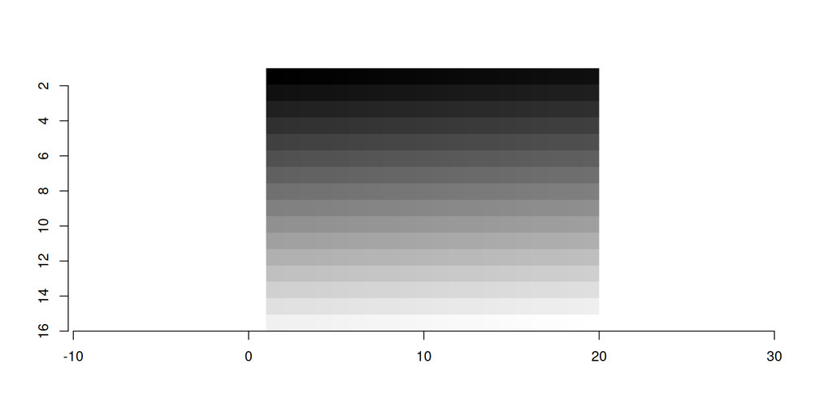

## Peut on compresser les Beatles ?

On va travailler sur la fameuse image de l’album Abbey Road des Beatles.

[figure not shown]

Pour la charger avec R, on utilise le package `imager` et la fonction `load.image`. puis la fonction `grayscale`pour bien s’assurer que l’image est codée en niveaux de gris.

[figure not shown]

L’objet obtenu est un `array` dont la première dimension est le nombre de pixels en ligne et la seconde dimension le nombre de pixel en colonnes. La troisème dimension est la profondeur et correspondrait au temps dan sun film par exemple et la dernière dimension est la couleur (on a donc 3 valeurs possibles sur cette dernière dimension dans le cas d’une image RGB et 1 dans le cas d’une image en niveau de gris).

Si on se concentre sur les deux premières dimensions, on a donc une matrice dont la valeur est le niveau de gris du pixel correspondant.

```
[1] 709 709   1   1
```

```
[1] 0.005176471
```

[figure not shown]

[figure not shown]

Pour rentrer dans le formalisme de l’ACP, on a besoin qu’une ligne soit un individu et une colonne une variable. Ici, le choix nous revient de définir comme on le souhaite ce qu’est un individu et une varaible.

On va découper l’image en buffer carré (patch, micro image) de coté $bs.$ Un individu sera un patch et une variable sera le niveau de gris dans un pixel particulier du patch.

On a donc $bs^2$ variables et $N_{buf} = (height/bs) * (width/bs)$ buffers/individus.

### Réduction de dimension par ACP

On va maintenant mettre en oeuvre une ACP, pour détermnier les composantes principales et on ne gardera quelques composantes pour réduire la dimension. On utilise `FactoMineR`.

- la matrice $1\times bs^2$ qui permet de reconstruire les 16 variables initiales avec l’information contenu dans ce premier buffer,
- les coefficients que chaque buffer individu attribue à ce premier buffer, soit $N_{buf}$

On sait q’un vecteur propre correspond à un patch de $bc\times bs$, on peut donc les visualiser sous cette forme

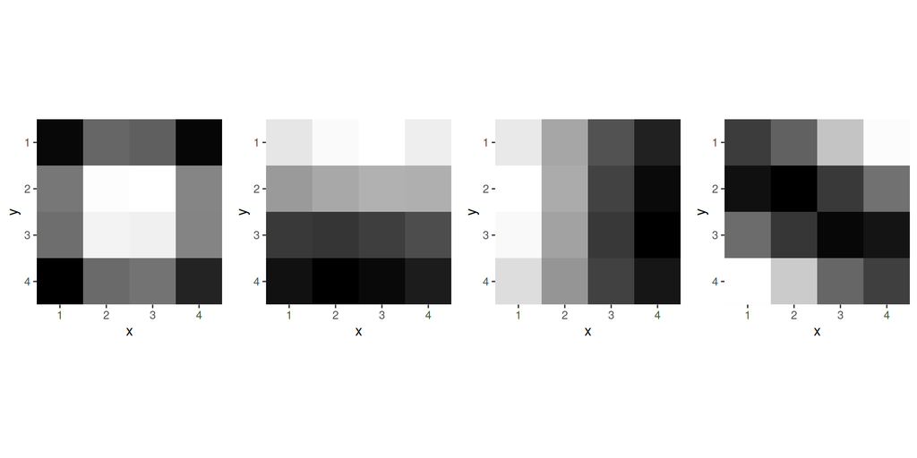

### Reconstruction avec une seule composante principale

[figure not shown]

```r
new_coord <- images_pca$ind$coord
reconstruction <- new_coord[, 1, drop = FALSE]%*% t(images_pca$svd$V)[1,]

n_row_block <- dim(image_cp)[1]/block_size
n_col_block <- dim(image_cp)[2]/block_size

test <- matrix(1:(712^2), ncol = 712)
test_block <- image2block(channel_matrix = test, block_size = 4)
ok <- block2image(test_block, nrow_img = 712, ncol_img = 712, block_size = 4)

X_reconstruction <- block2image(reconstruction, nrow_img = nrow(image_cp), ncol_img = ncol(image_cp), block_size = block_size )

img_1 <- as.cimg(array(X_reconstruction, dim=dim(image_cp)))
plot(img_1)
```

```r
df_1 <- as.data.frame(img_1)


p_1 <- ggplot(df_1,aes(x,y))+geom_raster(aes(fill=value)) +
   scale_y_continuous(trans=scales::reverse_trans(), expand = c(0,0)) + ## pour mettre l'image dans le bon sens et supprimer les bors gris
  scale_x_continuous(expand=c(0,0)) +
  scale_fill_gradient(low="black",high="white") + ## pour le noir et blanc
  theme(legend.position = "none")
```

```r
new_coord <- images_pca$ind$coord
reconstruction_2 <- new_coord[, 1:2]%*% t(images_pca$svd$V)[1:2,]

X_reconstruction_list_2 <- lapply(1:n_col_block, function(j){
  list_rows <- lapply(1:n_row_block, function(i){
    matrix( reconstruction_2[(j-1)*n_row_block + i,], ncol = block_size)
  })
  do.call(rbind, list_rows)
}
)

X_reconstruction_2 <- do.call(cbind, X_reconstruction_list_2)

df_2 <-as.cimg(array(X_reconstruction_2, dim=dim(image_cp))) %>% as.data.frame
p_2 <- ggplot(df_2,aes(x,y))+geom_raster(aes(fill=value)) +
   scale_y_continuous(trans=scales::reverse_trans(), expand = c(0,0)) + ## pour mettre l'image dans le bon sens et supprimer les bors gris
  scale_x_continuous(expand=c(0,0)) +
  scale_fill_gradient(low="black",high="white") + ## pour le noir et blanc
  theme(legend.position = "none")
```

[figure not shown]

Original Beatles

[figure not shown]

[figure not shown]